# London’s cultural venues

Dipankar Lahiri

2025-03-21

This is an analysis of data on cultural venues in London released by the Greater London Authority. The raw dataset categorizes London’s 10,003 cultural venues by 29 variables.

## Highlights of Findings

##### 1. Types of Cultural Venues in London

Pubs (4098) are the most common venue type. Large media production studios (5) are the rarest.

##### 2. Number of Venues across Boroughs

Westminster (1186) has the most cultural venues among the 33 London boroughs. The boroughs with the least cultural venues are Barking and Dagenham (85), Redbridge (101) and Sutton (103).

##### 3. Types of Venues across Boroughs

**Pubs:** The highest proportion of pubs to other venues is in City of London (215 of 340 = 63.2%). But central London has a low proportion of pubs overall - Hackney (26%), Tower Hamlets (30%) and Camden (30%) are the three boroughs with the lowest proportion of pubs. South London has the most pubs overall. The five boroughs which follow City of London in proportion of pubs - Kingston upon Thames (61%), Bexley (59%), Croydon (58%), Bromley (57%) and Richmond upon Thames (56%) - are all in south London. Four other boroughs have pubs being more than 50% of total venues - Havering (east London), Hillingdon (west London), Wandsworth (central London), Sutton (south London).

**Other Venue Types:** Haringey has the most proportion of legal street art walls (though only 4 boroughs have legal street art walls at all!). Barking and Dagenham have the most proportion of skate parks, Kensington and Chelsea leads in museums and galleries. Hackney leads in music and dance venues.

##### 4. Venue Density across London

The general trend is that the further the location is from the centre of the city, the less venues it has. However, there are some exceptions.

**Outliers**

- The greenland area around Richmond Park is a large area near the centre of the city with no cultural venues.
- Uxbridge, Romford are among locations further away from central London which have unusually high density of venues.
- Often, there is a high density of venues on certain roads or tube lines outside central London, like the A221 near Bexleyheath or the Elizabeth line from Ilford to Romford.

##### 5. Population Density and Venue Count

There is a significant positive correlation (0.69) between population density and total venue count. Boroughs with higher population density tend to have more venues overall and boroughs on the outskirts generally have low population densities and less venues.

**Outliers**

- Westminster and Camden have exceptionally high venue counts (z-scores > 2) relative to their population density. City of London also stands out (z-score > 1) despite having one of the lowest population densities.
- Newham and Kensington and Chelsea have fewer venues than expected based on population density.

##### 6. International Migration and Venues

There is a strong positive correlation (0.75) between net international migration and number of venues - meaning boroughs which have more international migration have more venues.

The number of commercial galleries and archives is most associated with international migration. Skate parks, set and exhibition building and co-working desk spaces are the venue types least associated with international migration.

**Outliers**

- Hackney stands out as a positive outlier, with significantly more venues than expected based on migration levels.
- Redbridge and Newham are negative outliers, having high net international migration but fewer venues than predicted.

## Data Cleaning, Preparation

- Of the 29 variables, some had very high number of NAs. All three logical variables had all values as NA, suggesting a data loading issue. Dropped three columns alternativenames, building_name, greenflagcommunityaward.
- Changed the class of the runtime column from character to date. This turned out to be needless as this has only one unique value, thus ruling out possibilities of time-series analysis.
- The dataset had duplicate columns for ward and borough codes from different sources. ward_2018_code and ward_code_2018, as well as ward_2018_name and ward_name_2018, followed a systematic NA pattern, indicating they represent the same data. Similarly, borough_code and gss_code overlapped. These were merged into single columns.
- Identified 15 columns that were narrow categorical variables to describe the venues, which have many missing values. These would be useful for venue-specific analysis, but would not help broader analysis. Dropped contact_name, additional_contact_name, address1, address2, address3, runtime, website, ward_2018_name_merged, ward_2018_code_merged, gss_code_merged, os_addressbase_uprn, rm_organisation_name, ward, ward_code.
- Dropped fid_london_ward as it was a numeric variable associated only with the 5 large media production studios (the rarest cultural venue type). Not useful to analyse overall data.

```r
df <- df %>% select(-c(alternativenames, building_name, greenflagcommunityaward, borough_name))
df$runtime <- as.Date(df$runtime, format = "%m/%d/%Y")
df$ward_2018_code_merged <- ifelse(!is.na(df$ward_2018_code), df$ward_2018_code, df$ward_code_2018)
df$ward_2018_name_merged <- ifelse(!is.na(df$ward_2018_name), df$ward_2018_name, df$ward_name_2018)
df$gss_code_merged <- ifelse(is.na(df$gss_code), df$borough_code, df$gss_code)
df <- df[, !(names(df) %in% c("ward_2018_code", "ward_code_2018", "ward_2018_name", "ward_name_2018"))]
df <- df[, !(names(df) %in% c("gss_code", "borough_code"))]
df <- df %>% select(-contact_name, -additional_contact_name, -address1, -address2, -address3, -runtime, -website, -ward_2018_name_merged, -ward_2018_code_merged, -gss_code_merged, -os_addressbase_uprn, -rm_organisation_name, -ward, -ward_code, -fid_london_ward)
```

The dataset now has 7 variables of two types. There are no missing values.

1. site_name, BOROUGH, Cultural Venue Type — Categorical variables to classify the venues.
2. easting, northing, latitude, longitude — Numeric variables to denote locations of venues.

## Summary Statistics

### List of Boroughs

```r
unique(df$BOROUGH)
```

```
##  [1] "Tower Hamlets"          "Camden"                 "Ealing"                 "Hammersmith and Fulham"
##  [5] "City of London"         "Newham"                 "Merton"                 "Wandsworth"
##  [9] "Barnet"                 "Brent"                  "Enfield"                "Kensington and Chelsea"
## [13] "Islington"              "Sutton"                 "Southwark"              "Haringey"
## [17] "Hackney"                "Lambeth"                "Greenwich"              "Hillingdon"
## [21] "Lewisham"               "Westminster"            "Harrow"                 "Hounslow"
## [25] "Richmond upon Thames"   "Bexley"                 "Waltham Forest"         "Redbridge"
## [29] "Croydon"                "Barking and Dagenham"   "Kingston upon Thames"   "Bromley"
## [33] "Havering"
```

All 33 London boroughs are represented in the dataset.

### List of Venue Types

```r
unique(df$`Cultural Venue Type`)
```

```
##  [1] "Archives"                        "Artists workspaces"              "Arts centres"
##  [4] "Cinemas"                         "Commercial galleries"            "Community centres"
##  [7] "Creative co-working desk space"  "Creative workspaces"             "Dance performance venues"
## [10] "Dance rehearsal studios"         "Fashion and design"              "Jewellery design"
## [13] "Large media production studios"  "Legal street art walls"          "LGBT+ night time venues"
## [16] "Libraries"                       "Live in artists' workspace"      "Makerspaces"
## [19] "Making and manufacturing"        "Museums and public galleries"    "Music (office based businesses)"
## [22] "Music recording studios"         "Music rehearsal studios"         "Music venues (all)"
## [25] "Music venues (grassroots)"       "Outdoor spaces for cultural use" "Prop and costume making"
## [28] "Pubs"                            "Set and exhibition building"     "Skate Parks"
## [31] "Textile design"                  "Theatre rehearsal studio"        "Theatres"
```

The 10,003 venues have 33 categories.

### Distribution of Venue Types

```r
category_counts <- df %>% count(`Cultural Venue Type`, name = "venue_count") %>% arrange(desc(venue_count))
print(category_counts)
```

```
## # A tibble: 33 × 2
##    `Cultural Venue Type`           venue_count
##    <chr>                                 <int>
##  1 Pubs                                   4098
##  2 Community centres                       903
##  3 Music venues (all)                      797
##  4 Archives                                556
##  5 Libraries                               342
##  6 Jewellery design                        315
##  7 Commercial galleries                    306
##  8 Music (office based businesses)         304
##  9 Dance rehearsal studios                 265
## 10 Theatres                                264
## # ℹ 23 more rows
```

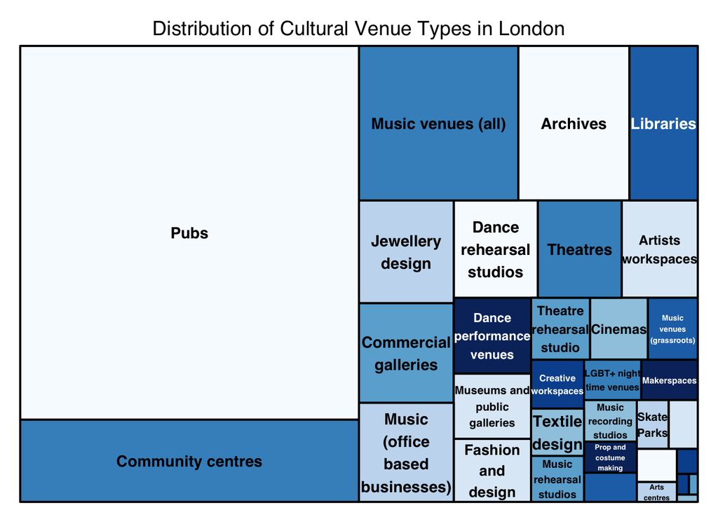

```r
treemap(category_counts,
        index = "Cultural Venue Type",
        vSize = "venue_count",
        title = "Distribution of Cultural Venue Types in London",
        palette = "Blues")
```

Pubs (4098) are the most common venue type. This is followed by Community centres (903), Music venues (797) and Archives (556). Of the 33 venue types, Large media production studios (5) is the rarest.

### Venues per Borough

```r
borough_counts <- df %>% count(BOROUGH, name = "venue_count") %>% arrange(desc(venue_count))
print(borough_counts)
```

```
## # A tibble: 33 × 2
##    BOROUGH        venue_count
##    <chr>                <int>
##  1 Westminster           1186
##  2 Camden                 892
##  3 Hackney                683
##  4 Islington              577
##  5 Southwark              535
##  6 Tower Hamlets          514
##  7 Lambeth                512
##  8 City of London         340
##  9 Wandsworth             301
## 10 Lewisham               293
## # ℹ 23 more rows
```

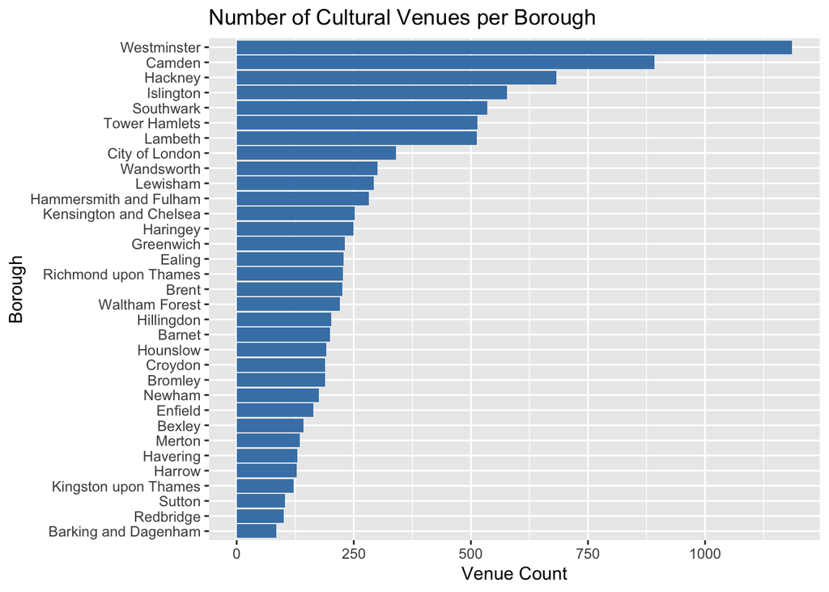

```r
ggplot(borough_counts, aes(x = reorder(BOROUGH, venue_count), y = venue_count)) +
  geom_bar(stat = "identity", fill = "steelblue") +
  coord_flip() +
  labs(title = "Number of Cultural Venues per Borough", x = "Borough", y = "Venue Count")
```

Westminster (1186) has the most cultural venues among the 33 London boroughs. Following closely are Camden (892) and Hackney (683). The boroughs with the least cultural venues are Barking and Dagenham (85), Redbridge (101) and Sutton (103).

## Mapping

### Venue mapping on geographical co-ordinates

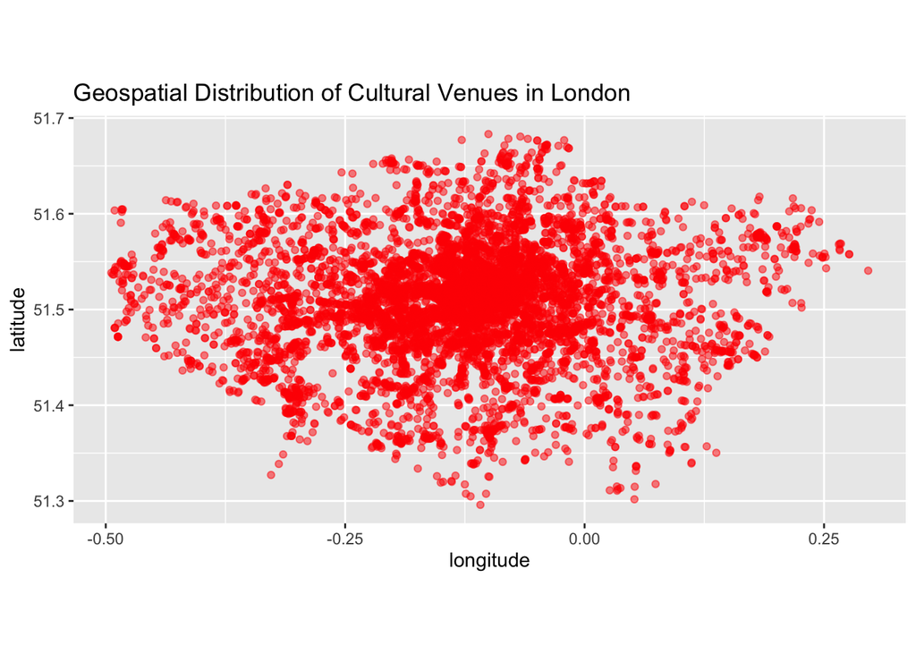

```r
ggplot(df, aes(x = longitude, y = latitude)) +
  geom_point(alpha = 0.5, color = "red") +
  coord_fixed() +
  labs(title = "Geospatial Distribution of Cultural Venues in London")
```

This shows venues are most concentrated in central London locations. The general trend is that the further the location is from the centre of the city, the less venues it has. However, there are some curiousities. There is a spot in the southwest of the city which has an unusually low density of venues - this turns out to be the large Richmond Park greenland area.

### Interactive Map

```r
leaflet(df) %>%
  addTiles() %>%
  addCircleMarkers(lng = ~longitude, lat = ~latitude, popup = ~site_name,
                   color = "red", fillOpacity = 0.5, radius = 3)
```

[interactive chart not shown]

**Zoom in on the map of London and click on individual venues to show the name of the venue (corresponding to site_name).**

A few more trends are visible on zooming in and out of the map. For example, Uxbridge, Romford are among locations further away from central London which have unusually high density of venues. Often, there is a high density of venues on certain roads or tube lines outside central London, like the A221 near Bexleyheath or the Elizabeth line from Ilford to Romford.

### Venue Distribution per Borough

```r
london_boroughs_sf <- st_read(shapefile_path)
london_boroughs_sf <- london_boroughs_sf %>%
  rename(BOROUGH = NAME)
borough_counts_sf <- london_boroughs_sf %>%
  left_join(borough_counts, by = "BOROUGH")

tm_shape(borough_counts_sf) +
  tm_polygons("venue_count", palette = "brewer.blues", title = "Cultural Venues per Borough")
```

```
## ── tmap v3 code detected ──────────────────────────────────────────────────────────────────────────────────────
```

```
## [v3->v4] `tm_tm_polygons()`: migrate the argument(s) related to the scale of the visual variable `fill` namely
## 'palette' (rename to 'values') to fill.scale = tm_scale(<HERE>).
## [v3->v4] `tm_polygons()`: migrate the argument(s) related to the legend of the visual variable `fill` namely
## 'title' to 'fill.legend = tm_legend(<HERE>)'
```

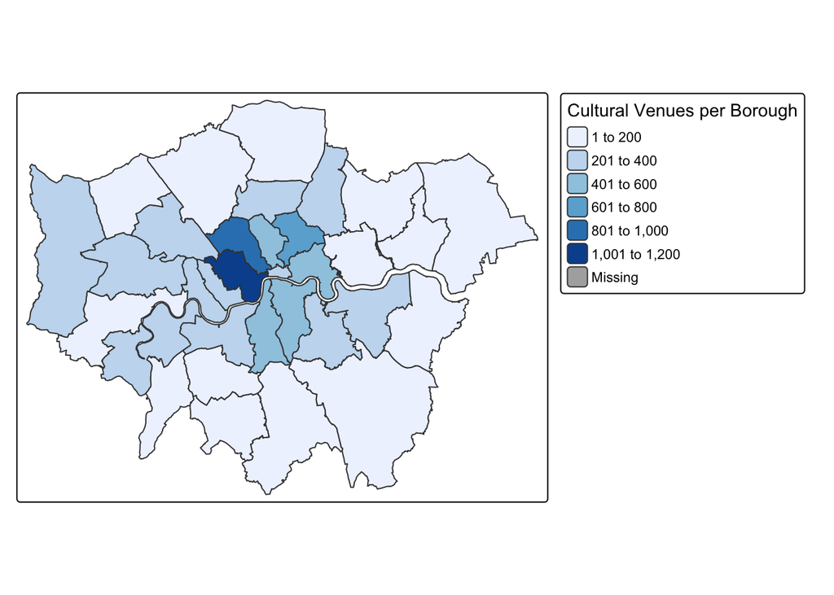

Westminster is the only borough with more than 1000 venues. Hillingdon, Richmond upon Thames and Waltham Forest are the only boroughs on London’s outer border with more than 200 venues.

## Venue Types across Boroughs

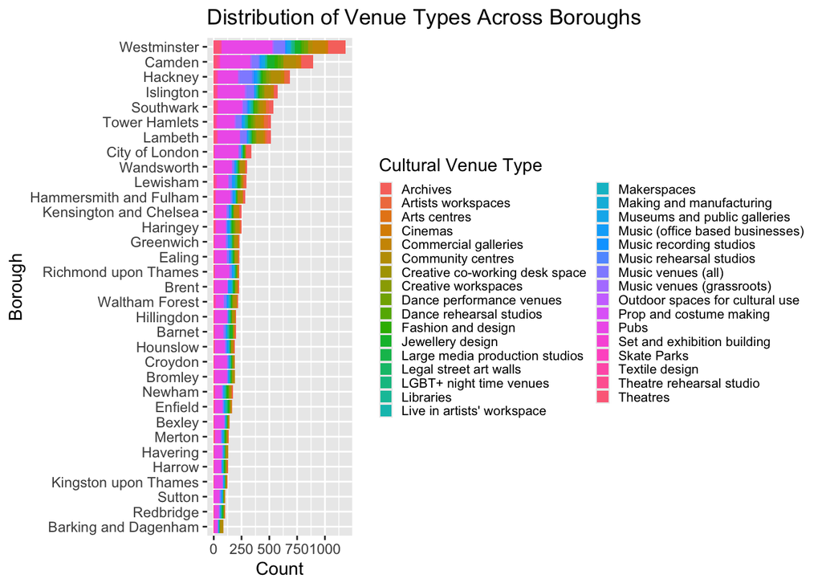

```r
df <- df %>%
  mutate(BOROUGH = fct_reorder(BOROUGH, (table(BOROUGH)[BOROUGH])))

ggplot(df, aes(x = BOROUGH, fill = `Cultural Venue Type`)) +
  geom_bar() +
  coord_flip() +
  labs(title = "Distribution of Venue Types Across Boroughs", x = "Borough", y = "Count") +
  guides(fill = guide_legend(ncol = 2)) +
  theme(legend.key.size = unit(0.3, "cm"),
        legend.text = element_text(size = 8))
```

This above graph shows some interesting trends. For example, Brent (226), Ealing (228) and Richmond upon Thames (227) have around the same number of total venues, but it is the southern borough of Richmond upon Thames which has more pubs (128) than the other two in the north (109 and 105). Among more central London boroughs, Islington (243 of 577 = 42.1%) and Lambeth (196 of 512 = 38.3%) have high proportion of pubs, Tower Hamlets (154 of 514 = 29.9%) and Hackney (178 of 683 = 26.1%) have low proportion of pubs. The highest proportion of pubs to total venues is in City of London(215 of 340 = 63.2%).

### Ranking Boroughs on Proportions of Venue Types

#### Pubs

```r
df %>%
  group_by(BOROUGH) %>%
  summarise(
    total_pubs = sum(`Cultural Venue Type` == "Pubs", na.rm = TRUE),
    total_venues = n(),
    percentage_pubs = (total_pubs / total_venues) * 100
  ) %>%
  arrange(desc(percentage_pubs))
```

```
## # A tibble: 33 × 4
##    BOROUGH              total_pubs total_venues percentage_pubs
##    <fct>                     <int>        <int>           <dbl>
##  1 City of London              215          340            63.2
##  2 Kingston upon Thames         74          122            60.7
##  3 Bexley                       85          143            59.4
##  4 Croydon                     110          189            58.2
##  5 Bromley                     108          189            57.1
##  6 Richmond upon Thames        128          227            56.4
##  7 Havering                     71          129            55.0
##  8 Hillingdon                  108          202            53.5
##  9 Wandsworth                  152          301            50.5
## 10 Sutton                       52          103            50.5
## # ℹ 23 more rows
```

This above table reveals that even though the central borough of City of London has the highest proportion of pubs to other venues, the five boroughs which follow it are all in south London - Kingston upon Thames (61%), Bexley (59%), Croydon (58%), Bromley (57%) and Richmond upon Thames (56%). A total of 10 boroughs have pubs being more than 50% of the total venues, none of these boroughs except City of London and Wandsworth are in central London. The three central London boroughs of Hackney (26%), Tower Hamlets (30%) and Camden (30%) are in fact the three boroughs with lowest proportion of pubs.

#### LGBT+ Night Time Venues

```r
df %>%
  group_by(BOROUGH) %>%
  summarise(
    total_venues = n(),
    total_lgbt_venues = sum(`Cultural Venue Type` == "LGBT+ night time venues", na.rm = TRUE),
    percent_lgbt_venues = (total_lgbt_venues / total_venues) * 100
  ) %>%
  arrange(desc(percent_lgbt_venues))
```

```
## # A tibble: 33 × 4
##    BOROUGH        total_venues total_lgbt_venues percent_lgbt_venues
##    <fct>                 <int>             <int>               <dbl>
##  1 Westminster            1186                22               1.85
##  2 Tower Hamlets           514                 9               1.75
##  3 Lambeth                 512                 8               1.56
##  4 Hackney                 683                 9               1.32
##  5 Waltham Forest          220                 2               0.909
##  6 Islington               577                 5               0.867
##  7 Greenwich               231                 2               0.866
##  8 Camden                  892                 7               0.785
##  9 Merton                  135                 1               0.741
## 10 Wandsworth              301                 2               0.664
## # ℹ 23 more rows
```

#### Legal Street Art Walls

```r
df %>%
  group_by(BOROUGH) %>%
  summarise(
    total_venues = n(),
    total_street_art = sum(`Cultural Venue Type` == "Legal street art walls", na.rm = TRUE),
    percent_street_art = (total_street_art / total_venues) * 100
  ) %>%
  arrange(desc(percent_street_art))
```

```
## # A tibble: 33 × 4
##    BOROUGH              total_venues total_street_art percent_street_art
##    <fct>                       <int>            <int>              <dbl>
##  1 Haringey                      249                2              0.803
##  2 Lambeth                       512                2              0.391
##  3 Tower Hamlets                 514                1              0.195
##  4 Camden                        892                1              0.112
##  5 Barking and Dagenham           85                0              0
##  6 Redbridge                     101                0              0
##  7 Sutton                        103                0              0
##  8 Kingston upon Thames          122                0              0
##  9 Harrow                        128                0              0
## 10 Havering                      129                0              0
## # ℹ 23 more rows
```

#### Skate Parks

```r
df %>%
  group_by(BOROUGH) %>%
  summarise(
    total_venues = n(),
    total_skate_parks = sum(`Cultural Venue Type` == "Skate Parks", na.rm = TRUE),
    percent_skate_parks = (total_skate_parks / total_venues) * 100
  ) %>%
  arrange(desc(percent_skate_parks))
```

```
## # A tibble: 33 × 4
##    BOROUGH              total_venues total_skate_parks percent_skate_parks
##    <fct>                       <int>             <int>               <dbl>
##  1 Barking and Dagenham           85                 2               2.35
##  2 Hillingdon                    202                 4               1.98
##  3 Enfield                       163                 3               1.84
##  4 Haringey                      249                 4               1.61
##  5 Croydon                       189                 3               1.59
##  6 Bromley                       189                 2               1.06
##  7 Lambeth                       512                 5               0.977
##  8 Sutton                        103                 1               0.971
##  9 Waltham Forest                220                 2               0.909
## 10 Kingston upon Thames          122                 1               0.820
## # ℹ 23 more rows
```

Here’s borough-wise rankings for a few combinations of venue types.

#### Archives, Libraries

```r
df %>%
  group_by(BOROUGH) %>%
  summarise(
    total_venues = n(),
    total_archives_libraries = sum(`Cultural Venue Type` %in% c("Archives", "Libraries"), na.rm = TRUE),
    percent_archives_libraries = (total_archives_libraries / total_venues) * 100
  ) %>%
  arrange(desc(percent_archives_libraries))
```

```
## # A tibble: 33 × 4
##    BOROUGH                total_venues total_archives_libraries percent_archives_libraries
##    <fct>                         <int>                    <int>                      <dbl>
##  1 City of London                  340                       53                      15.6
##  2 Westminster                    1186                      166                      14.0
##  3 Redbridge                       101                       14                      13.9
##  4 Camden                          892                      115                      12.9
##  5 Barnet                          199                       24                      12.1
##  6 Hillingdon                      202                       24                      11.9
##  7 Enfield                         163                       19                      11.7
##  8 Kensington and Chelsea          252                       25                       9.92
##  9 Newham                          176                       17                       9.66
## 10 Hounslow                        191                       18                       9.42
## # ℹ 23 more rows
```

#### Museums, Art Centres, Galleries

```r
df %>%
  group_by(BOROUGH) %>%
  summarise(
    total_venues = n(),
    total_museums_galleries = sum(`Cultural Venue Type` %in% c("Museums and public galleries", "Arts centres", "Commercial galleries"), na.rm = TRUE),
    percent_museums_galleries = (total_museums_galleries / total_venues) * 100
  ) %>%
  arrange(desc(percent_museums_galleries))
```

```
## # A tibble: 33 × 4
##    BOROUGH                total_venues total_museums_galleries percent_museums_galleries
##    <fct>                         <int>                   <int>                     <dbl>
##  1 Kensington and Chelsea          252                      36                     14.3
##  2 Westminster                    1186                     147                     12.4
##  3 Tower Hamlets                   514                      35                      6.81
##  4 Camden                          892                      60                      6.73
##  5 Southwark                       535                      28                      5.23
##  6 Richmond upon Thames            227                      11                      4.85
##  7 Greenwich                       231                      11                      4.76
##  8 Harrow                          128                       6                      4.69
##  9 Hackney                         683                      30                      4.39
## 10 Islington                       577                      24                      4.16
## # ℹ 23 more rows
```

#### Cinema, Theatre

```r
df %>%
  group_by(BOROUGH) %>%
  summarise(
    total_venues = n(),
    total_cinemas_theatres = sum(`Cultural Venue Type` %in% c("Cinemas", "Theatre rehearsal studio", "Theatres"), na.rm = TRUE),
    percent_cinemas_theatres = (total_cinemas_theatres / total_venues) * 100
  ) %>%
  arrange(desc(percent_cinemas_theatres))
```

```
## # A tibble: 33 × 4
##    BOROUGH                total_venues total_cinemas_theatres percent_cinemas_theatres
##    <fct>                         <int>                  <int>                    <dbl>
##  1 Westminster                    1186                     89                     7.50
##  2 Southwark                       535                     38                     7.10
##  3 Lambeth                         512                     36                     7.03
##  4 Haringey                        249                     17                     6.83
##  5 Camden                          892                     55                     6.17
##  6 Hammersmith and Fulham          282                     17                     6.03
##  7 Kensington and Chelsea          252                     15                     5.95
##  8 Merton                          135                      8                     5.93
##  9 Newham                          176                     10                     5.68
## 10 Islington                       577                     32                     5.55
## # ℹ 23 more rows
```

#### Music, Dance

```r
df %>%
  group_by(BOROUGH) %>%
  summarise(
    total_venues = n(),
    total_music_dance = sum(`Cultural Venue Type` %in% c("Dance performance venues", "Dance rehearsal studios",
                                                          "Music (office based businesses)", "Music recording studios",
                                                          "Music rehearsal studios", "Music venues (all)", "Music venues (grassroots)"), na.rm = TRUE),
    percent_music_dance = (total_music_dance / total_venues) * 100
  ) %>%
  arrange(desc(percent_music_dance))
```

```
## # A tibble: 33 × 4
##    BOROUGH              total_venues total_music_dance percent_music_dance
##    <fct>                       <int>             <int>               <dbl>
##  1 Hackney                       683               205                30.0
##  2 Sutton                        103                26                25.2
##  3 Lewisham                      293                72                24.6
##  4 Islington                     577               130                22.5
##  5 Lambeth                       512               101                19.7
##  6 Tower Hamlets                 514               101                19.6
##  7 Waltham Forest                220                43                19.5
##  8 Ealing                        228                44                19.3
##  9 Greenwich                     231                44                19.0
## 10 Richmond upon Thames          227                42                18.5
## # ℹ 23 more rows
```

Quite a few interesting trends can be seen from the above tables. For example, Haringey has the most proportion of legal street art walls (though only 4 boroughs have legal street art walls at all!), Barking and Dagenham have the most proportion of skate parks, Kensington and Chelsea leads in museums and galleries, Hackney leads in music and dance venues.

A few ways forward with this data could be to: 1. Make interactive maps with individual venue types or groups of venue types. 2. Group boroughs into regions and follow hypotheses like ‘Does South London have the most pubs?’ or ‘Do boroughs of outer London have more spaces for physical activity (like skating)?’

I will now move on to collate this dataset with a dataset on population and demographic statistics released by the ONS to explore the distribution of cultural venues by population of London’s boroughs.

## Venues per Population

```r
pop_df <- pop_df %>%
  filter(Geography1 == "London Borough")
pop_df <- pop_df %>% clean_names()
pop_df$name <- trimws(tolower(as.character(pop_df$name)))
london_boroughs_sf$BOROUGH <- trimws(tolower(as.character(london_boroughs_sf$BOROUGH)))
pop_df$HECTARES <- london_boroughs_sf$HECTARES[match(pop_df$name, london_boroughs_sf$BOROUGH)]
pop_df$Population_Density <- pop_df$estimated_population_mid_2019 / pop_df$HECTARES
borough_counts <- borough_counts %>% mutate(BOROUGH = tolower(BOROUGH))
pop_df <- pop_df %>% mutate(name = tolower(name))

venue_per_capita <- borough_counts %>%
  left_join(pop_df, by = c("BOROUGH" = "name")) %>%
  mutate(
    venues_per_1000 = venue_count / (estimated_population_mid_2019 / 1000)
  ) %>%
  select(BOROUGH, venue_count, estimated_population_mid_2019, Population_Density, venues_per_1000) %>%
  arrange(desc(venues_per_1000))


print(venue_per_capita)
```

```
## # A tibble: 33 × 5
##    BOROUGH                venue_count estimated_population_mid_2019 Population_Density venues_per_1000
##    <chr>                        <int>                         <dbl>              <dbl>           <dbl>
##  1 city of london                 340                          9721               30.9           35.0
##  2 westminster                   1186                        261317              119.             4.54
##  3 camden                         892                        270029              124.             3.30
##  4 hackney                        683                        281120              148.             2.43
##  5 islington                      577                        242467              163.             2.38
##  6 southwark                      535                        318830              107.             1.68
##  7 kensington and chelsea         252                        156129              126.             1.61
##  8 tower hamlets                  514                        324745              151.             1.58
##  9 lambeth                        512                        326034              120.             1.57
## 10 hammersmith and fulham         282                        185143              108.             1.52
## # ℹ 23 more rows
```

### Correlation Tests, Linear Modelling

This shows City of London (35 venues per 1000 people) has a far higher number of venues per capita than all other boroughs. The other central London boroughs of Westminster, Camden, Hackney and Islington are the other boroughs to have a venue per capita count of more than 2. The eastern boroughs of Barking and Dagenham and Redbridge are the two boroughs with the lowest venues per capita population (less than 0.4 venues per 1000 people). This leads to the question - does population density have a correlation with venues per capita?

```r
cor(venue_per_capita$Population_Density, venue_per_capita$venue_count)
```

```
## [1] 0.6939588
```

```r
cor(venue_per_capita$Population_Density, venue_per_capita$venues_per_1000) ## Insignificant negative correlation returned
```

```
## [1] -0.08533668
```

There is a significant positive correlation (0.69) between population density and total venue count. Boroughs with higher population density tend to have more venues overall - most central London boroughs have high population densities and many venues. Boroughs on the outskirts generally have low population densities and less venues. But there are exceptions to this.

```r
model <- lm(venue_count ~ Population_Density, data = venue_per_capita)
venue_per_capita$residuals <- resid(model)

venue_per_capita %>% arrange(desc(residuals))
```

```
## # A tibble: 33 × 6
##    BOROUGH              venue_count estimated_population_mid_2019 Population_Density venues_per_1000 residuals
##    <chr>                      <int>                         <dbl>              <dbl>           <dbl>     <dbl>
##  1 westminster                 1186                        261317              119.            4.54      696.
##  2 camden                       892                        270029              124.            3.30      380.
##  3 city of london               340                          9721               30.9          35.0       221.
##  4 bromley                      189                        332336               22.1           0.569     107.
##  5 hillingdon                   202                        306870               26.5           0.658     101.
##  6 southwark                    535                        318830              107.            1.68       96.0
##  7 richmond upon thames         227                        198019               33.7           1.15       96.0
##  8 hackney                      683                        281120              148.            2.43       70.8
##  9 havering                     129                        259552               22.7           0.497      44.5
## 10 lambeth                      512                        326034              120.            1.57       17.8
## # ℹ 23 more rows
```

```r
venue_per_capita %>% arrange(residuals)
```

```
## # A tibble: 33 × 6
##    BOROUGH                venue_count estimated_population_mid_2…¹ Population_Density venues_per_1000 residuals
##    <chr>                        <int>                        <dbl>              <dbl>           <dbl>     <dbl>
##  1 kensington and chelsea         252                       156129              126.            1.61     -269.
##  2 newham                         176                       353134               91.5           0.498    -199.
##  3 hammersmith and fulham         282                       185143              108.            1.52     -163.
##  4 barking and dagenham            85                       212906               56.3           0.399    -142.
##  5 haringey                       249                       268647               90.8           0.927    -123.
##  6 redbridge                      101                       305222               54.1           0.331    -116.
##  7 tower hamlets                  514                       324745              151.            1.58     -111.
##  8 islington                      577                       242467              163.            2.38     -101.
##  9 merton                         135                       206548               54.9           0.654     -85.6
## 10 brent                          226                       329771               76.3           0.685     -84.9
## # ℹ 23 more rows
## # ℹ abbreviated name: ¹estimated_population_mid_2019
```

```r
venue_per_capita$z_residuals <- scale(venue_per_capita$residuals)
venue_per_capita %>% filter(abs(z_residuals) > 1)
```

```
## # A tibble: 5 × 7
##   BOROUGH       venue_count estimated_population…¹ Population_Density venues_per_1000 residuals z_residuals[,1]
##   <chr>               <int>                  <dbl>              <dbl>           <dbl>     <dbl>           <dbl>
## 1 city of lond…         340                   9721               30.9          35.0        221.            1.26
## 2 westminster          1186                 261317              119.            4.54       696.            3.97
## 3 camden                892                 270029              124.            3.30       380.            2.17
## 4 kensington a…         252                 156129              126.            1.61      -269.           -1.54
## 5 newham                176                 353134               91.5           0.498     -199.           -1.14
## # ℹ abbreviated name: ¹estimated_population_mid_2019
```

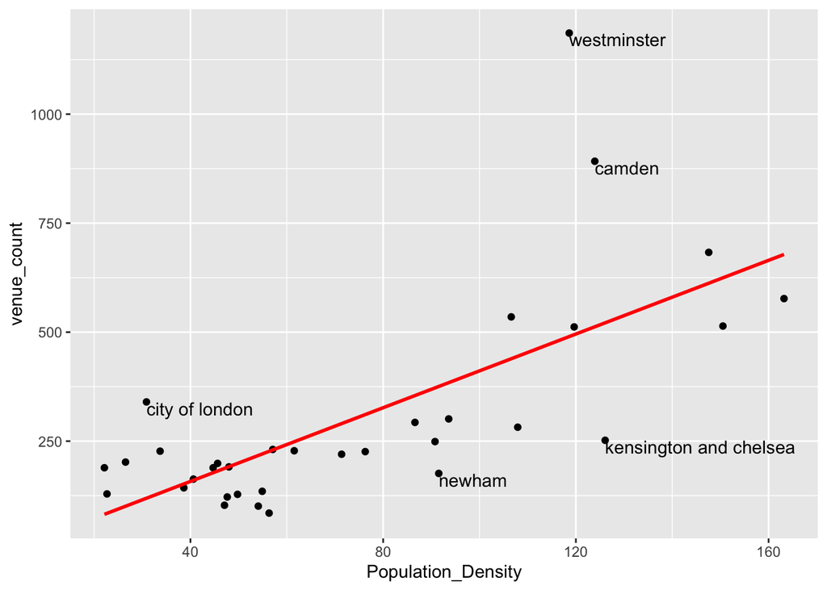

```r
ggplot(venue_per_capita, aes(x = Population_Density, y = venue_count)) +
  geom_point() +
  geom_smooth(method = "lm", se = FALSE, color = "red") +
  geom_text(aes(label = ifelse(abs(z_residuals) > 1, BOROUGH, "")), hjust = 0, vjust = 1)
```

A linear model helps to identify outliers in the strong positive correlation between population density and venue count. Westminster and Camden have exceptionally high venue counts (z-scores > 2) relative to their population density. City of London also stands out (z-score > 1) despite having one of the lowest population densities. Newham and Kensington and Chelsea have fewer venues than expected based on population density.

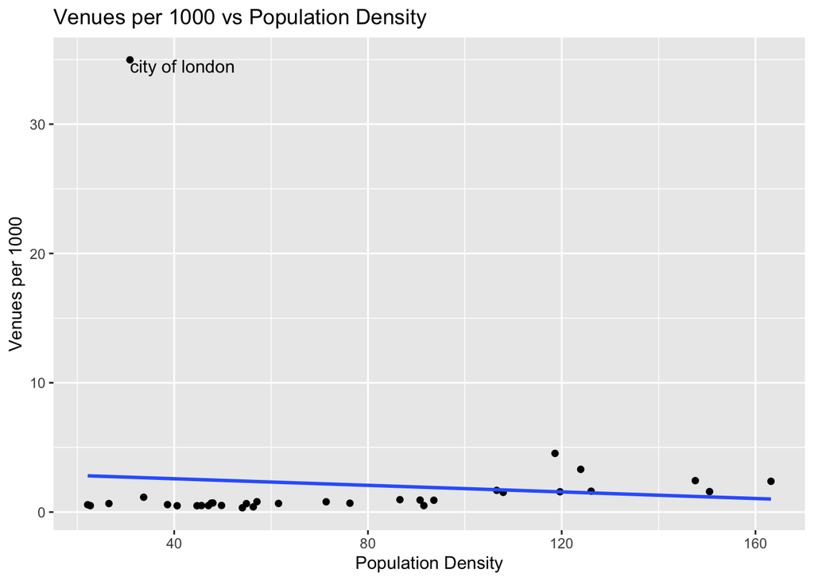

```r
venue_per_capita$z_venues_per_1000 <- scale(venue_per_capita$venues_per_1000)

ggplot(venue_per_capita, aes(x = Population_Density, y = venues_per_1000)) +
  geom_point() +
  geom_smooth(method = "lm", se = FALSE) +
  geom_text(aes(label = ifelse(abs(z_venues_per_1000) > 2, BOROUGH, "")), hjust = 0, vjust = 1) +
  labs(title = "Venues per 1000 vs Population Density", x = "Population Density", y = "Venues per 1000")
```

City of London is a clear outlier, with a very high venues-per-1000 rate despite its low population density.

## International Migration ane Venues

```r
df$BOROUGH <- tolower(trimws(df$BOROUGH))
pop_df$name <- tolower(trimws(pop_df$name))
venue_per_capita$BOROUGH <- tolower(trimws(venue_per_capita$BOROUGH))

df <- df %>%
  left_join(pop_df %>% select(name, international_migration_net), by = c("BOROUGH" = "name")) %>%
  left_join(venue_per_capita %>% select(BOROUGH, venue_count), by = "BOROUGH")

cor(df$international_migration_net, df$venue_count, use = "complete.obs")
```

```
## [1] 0.7455101
```

```r
df %>%
  group_by(`Cultural Venue Type`) %>%
  summarise(avg_migration = mean(international_migration_net, na.rm = TRUE)) %>%
  arrange(desc(avg_migration))
```

```
## # A tibble: 33 × 2
##    `Cultural Venue Type`           avg_migration
##    <chr>                                   <dbl>
##  1 Commercial galleries                    5340.
##  2 Archives                                5196.
##  3 Jewellery design                        4843.
##  4 LGBT+ night time venues                 4791.
##  5 Dance performance venues                4278.
##  6 Museums and public galleries            4236.
##  7 Theatre rehearsal studio                4214.
##  8 Cinemas                                 4062.
##  9 Outdoor spaces for cultural use         4056
## 10 Fashion and design                      3966.
## # ℹ 23 more rows
```

There is a strong positive correlation (0.75) between net international migration and number of venues. Commercial galleries and archives are the venue types most associated with net international migration. Skate parks, set and exhibition building and co-working desk spaces are the venue types least associated with net international migration.

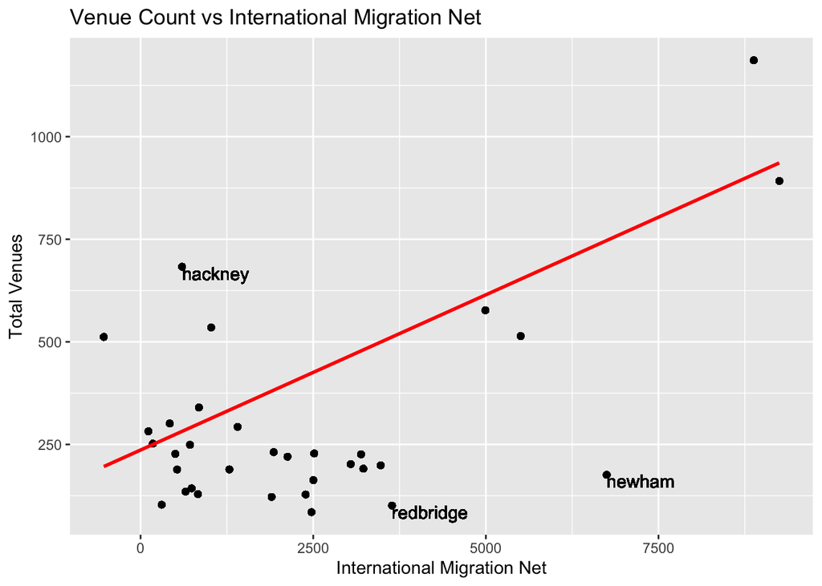

```r
model <- lm(venue_count ~ international_migration_net, data = df)

df$residuals <- resid(model)
df$z_residuals <- scale(df$residuals)

ggplot(df, aes(x = international_migration_net, y = venue_count)) +
  geom_point() +
  geom_smooth(method = "lm", se = FALSE, color = "red") +
  geom_text(aes(label = ifelse(abs(z_residuals) > 1.5, BOROUGH, "")), hjust = 0, vjust = 1) +
  labs(title = "Venue Count vs International Migration Net",
       x = "International Migration Net",
       y = "Total Venues")
```

A linear model confirms a strong positive relationship between net international migration and total venue count. Hackney stands out as a positive outlier, with significantly more venues than expected based on migration levels. In contrast, Redbridge and Newham are negative outliers, having high net international migration but fewer venues than predicted.